# Assignment 8

Rebecca Bishop

12/5/2021

## Your assignment

The goals for this assignment are to:

- practice making maps with the various packages
- think about composition and the grammar of graphics
- critique various maps

*By the end of the assignment* you should have several static maps displaying the datasets we’ve used in the last few weeks.

# Task 1: Show me your ugly maps!!

Find 2 examples of maps that you think are ‘bad’.

*Bad* maps are “maps where the graphic is unclear, confusing, or deceiving.”

**MAP 1:** Version 1: https://i.redd.it/q9jwbwejrvr71.png Version 2 (page 12): https://www.bc.edu/content/dam/files/centers/jesinst/pdf/Grim-globalReligion-full.pdf Apparently there is an entire reddit thread dedicated to bad maps. The vast majority of the posts are maps where entire countries are missing or placed in the wrong location. I did visit this thread for inspiration and found the linked gem above. I tried to find the original through the Pew Research Center, and had some trouble, but was able to find the report from Pew on Boston College’s site (Version 2). Strangely enough, the 2nd version in the report(published in 2012) is even worse than the 1st version (but are representing the same data). There is no key!

While this map was originally posted because Tajikistan and Kyrgyzstan we eliminated from the map (and apart of China), I found this to be a “bad” map for other reasons. First and foremost, it’s visually confusing. I had to look at it at least a couple of times before I could really understand the data that is trying to be communicated. I think one of the most off-putting things about this map is the amount of red that is used. Obviously, Christianity is a predominate religion and that is why we are seeing red… but, I think a different color palette could have been used. They have chosen to use primary colors with red and green at the top of the pack. What about all the color blind people out there?? Also, the use darker and lighter hues (where a darker color represents greater prevalence of a religion) is so strange here, especially with a thresh hold of 90%. The graph is titled “The largest religious groups worldwide.” The greater than 90% statistic is significant - we can understand what that means. But what does <90% tell us? Virtually nothing. Countries with say 5% Christian population and countries with 88% Christian population are represented here equally. In the <90% countries, are there other dominate religions at play (other than the one listed as less than 90%)? If a country is less than say 90% Christian, where is the cutoff in percentage before you say that this country is less than 90% Jewish? I think it detracts from the point of the graphic. Also, they have Isreal magnified. Why? Because it’s so small? There are plenty of other really small countries on the map that aren’t highlighted. What is the purpose of the magnification?

To better this map, I would change the color story to softer hues and eliminate the use of red and green (being mindful of color blindness). I would also change the use of the <90% statistic, by eliminating it all together - or- being more concise about why a country is still being assigned “Christian” or “Muslim” (when below 90%) by giving a more precise range- such as 50-90% of the population is Christian. I would also either 1) eliminate the magnification -or- 2) give a reason for it -or- 3) make the map bigger so that we can see even smaller countries. Last but not least, I’d make sure Tajikistan and Kyrgyzstan were on the map.

**MAP 2:** Figure 1 from: https://reader.elsevier.com/reader/sd/pii/S2351989417302640?token=9ED269C8678790CCD7432E337935BA3168CA6D94BF24CBC86878303E43EAF6A65D916C5A50F4144230B227C05ABC5C3E&originRegion=us-east-1&originCreation=20211206175326

To be honest, I’m not quite sure what I am looking at when I see this graphic. I *believe* the shaded areas are supposed to be “regions.” How these regions are defined is neither explained in the actual “Materials and Methods” section where the figure is referenced nor in the actual caption. Who is defining these regions? If these are indeed geographical regions, why is there a blank space in the middle of the map? Also, why are there spaces between regions and overlap of others? It just seems truly bizarre to me. And the way the regions are drawn over just a map of the US is extremely off-putting. If your regions extend beyond the boundaries of the US, at the very least you could do an outline of Canada to the North and Mexico to the south (without any other specific features) to give the reader some sort of reference point (and also explain why the boundaries extend past the bounds of the US). Finally, I feel like it’s a map that provides us with very little information - almost to the point where the minimalism is not doing the researchers or readers any favors.

I would instead put the names of the migration stations directly on the map (as there are so few of them), use the arrows to name the regions instead. I would also redraw the regions, extend the map (while still making the US the highlighted area by blurring its edges), and use the caption instead to expand upon info regarding the exact definition of these regional boundaries.

# Task 2: Load your libraries and build a dataframe

You can choose whichever datasets you’d like from the past several months as the subject for your mapping. You’ll need to use at least one tabular join, one spatial join, and one extraction to create the dataframe. Load the packages, the data, and make sure everything is projected here. Give me a sense for what you are hoping to map.

```r
library(tidyverse)
library(pander)
library(sf)
library(terra)
library(units)
library(ggmap)
```

```r
#ggmap "allows easy downloads of basemaps from Google (requires a key) and Stamen for use in mapping (and within ggplot2)."
library(cartogram)
#"Cartogram package facilitates thematic changes on the geometry based on other attributes (e.g. population)"
library(patchwork)
#"patchwork package allows easy composition of multi-figure plots"
library(tmap)
library(viridis)
```

For ease of use and learning (and in the interest of time), I am going to follow along with the example you have provided and work with the data from Assignment 7. *BACK FROM THE FUTURE(near the end of the assignment)*: I can confidently say that working with this data again today has really solidified some of these concepts for me (and I think I am finally getting the hang of it!)

```r
files<-list.files("/opt/data/session16/", full.names = TRUE)
files
```

```
## [1] "/opt/data/session16//Mammals_total_richness.tif"
## [2] "/opt/data/session16//Mammals_total_richness.tif.aux.xml"
## [3] "/opt/data/session16//Mammals_total_richness.tif.ovr"
## [4] "/opt/data/session16//Mammals_total_richness.tif.vat.dbf"
## [5] "/opt/data/session16//Regval.tif"
## [6] "/opt/data/session16//reg_pas.dbf"
## [7] "/opt/data/session16//reg_pas.prj"
## [8] "/opt/data/session16//reg_pas.shp"
## [9] "/opt/data/session16//reg_pas.shx"
```

```r
#1) Loading regional protected area shapefiles
pas.proc<-st_read(files[8])
files2<-list.files("/opt/data/session04/", pattern= "*.shp", full.names = TRUE)
files2
```

```
## [1] "/opt/data/session04//ID.shp"
## [2] "/opt/data/session04//regionalPAs1.shp"
## [3] "/opt/data/session04//regionalPAs2.shp"
## [4] "/opt/data/session04//regionalPAs3.shp"
## [5] "/opt/data/session04//regionalcessions.shp"
## [6] "/opt/data/session04//regionalstates.shp"
```

```r
pas.desig<-st_read(files2[2])
#2) Loading rasters
files
```

```
## [1] "/opt/data/session16//Mammals_total_richness.tif"
## [2] "/opt/data/session16//Mammals_total_richness.tif.aux.xml"
## [3] "/opt/data/session16//Mammals_total_richness.tif.ovr"
## [4] "/opt/data/session16//Mammals_total_richness.tif.vat.dbf"
## [5] "/opt/data/session16//Regval.tif"
## [6] "/opt/data/session16//reg_pas.dbf"
## [7] "/opt/data/session16//reg_pas.prj"
## [8] "/opt/data/session16//reg_pas.shp"
## [9] "/opt/data/session16//reg_pas.shx"
```

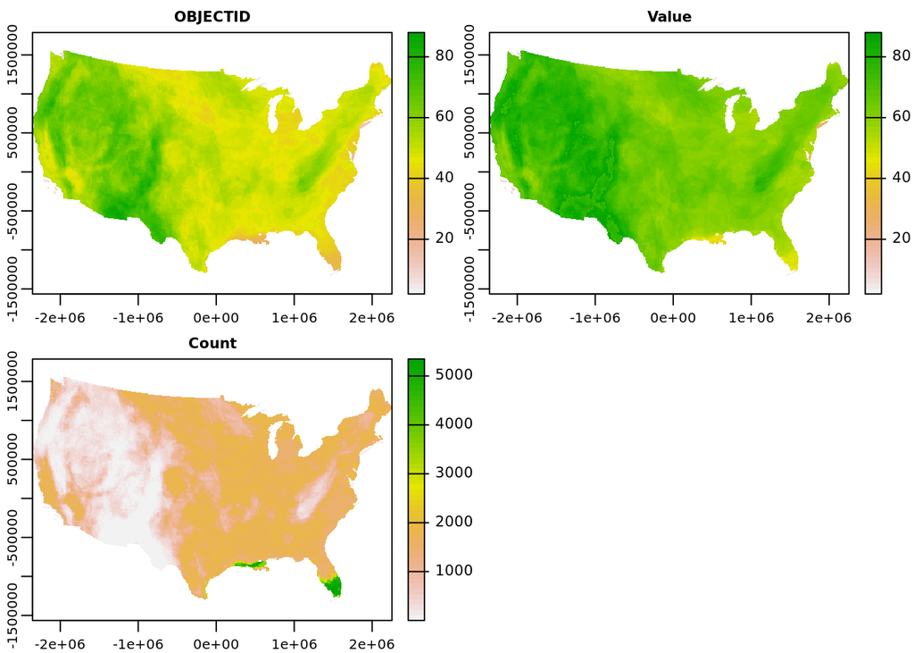

```r
mammal.rich<-rast(files[1])
landval<-rast(files[5])
#catalyzing mammal rich rast to get "continuous data "value" data
mammal.rich<-catalyze(mammal.rich)
plot(mammal.rich)
```

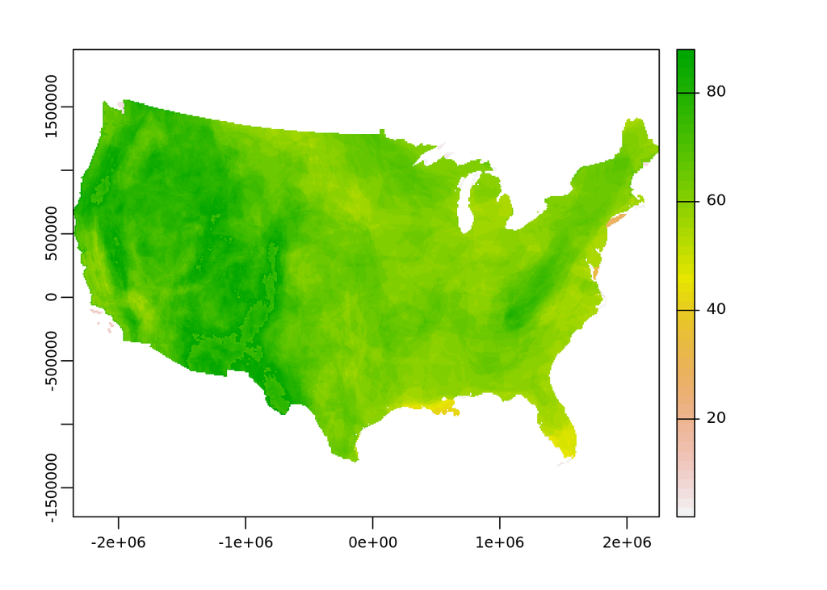

```r
mammal.rich<-mammal.rich[[2]]
plot(mammal.rich)
```

Checking geometries and CRS on shape files

```r
all(st_is_valid(pas.proc))
```

```
## [1] FALSE
```

```r
#FALSE. Need to make valid
pas.proc.valid<-st_make_valid(pas.proc)
all(st_is_valid(pas.proc.valid))
```

```
## [1] TRUE
```

```r
#True. Fixed
all(st_is_valid(pas.desig))
```

```
## [1] FALSE
```

```r
#FALSE
pas.desig.valid<-st_make_valid(pas.desig)
all(st_is_valid(pas.desig.valid))
```

```
## [1] TRUE
```

```r
#True. Fixed
st_crs(pas.desig.valid) == st_crs(pas.proc.valid)
```

```
## [1] TRUE
```

```r
#TRUE
st_crs(pas.desig.valid)
```

```
## Coordinate Reference System:
##   User input: USA_Contiguous_Albers_Equal_Area_Conic_USGS_version
##   wkt:
## PROJCRS["USA_Contiguous_Albers_Equal_Area_Conic_USGS_version",
##     BASEGEOGCRS["NAD83",
##         DATUM["North American Datum 1983",
##             ELLIPSOID["GRS 1980",6378137,298.257222101,
##                 LENGTHUNIT["metre",1]]],
##         PRIMEM["Greenwich",0,
##             ANGLEUNIT["Degree",0.0174532925199433]]],
##     CONVERSION["USA_Contiguous_Albers_Equal_Area_Conic_USGS_version",
##         METHOD["Albers Equal Area",
##             ID["EPSG",9822]],
##         PARAMETER["Latitude of false origin",23,
##             ANGLEUNIT["Degree",0.0174532925199433],
##             ID["EPSG",8821]],
##         PARAMETER["Longitude of false origin",-96,
##             ANGLEUNIT["Degree",0.0174532925199433],
##             ID["EPSG",8822]],
##         PARAMETER["Latitude of 1st standard parallel",29.5,
##             ANGLEUNIT["Degree",0.0174532925199433],
##             ID["EPSG",8823]],
##         PARAMETER["Latitude of 2nd standard parallel",45.5,
##             ANGLEUNIT["Degree",0.0174532925199433],
##             ID["EPSG",8824]],
##         PARAMETER["Easting at false origin",0,
##             LENGTHUNIT["metre",1],
##             ID["EPSG",8826]],
##         PARAMETER["Northing at false origin",0,
##             LENGTHUNIT["metre",1],
##             ID["EPSG",8827]]],
##     CS[Cartesian,2],
##         AXIS["(E)",east,
##             ORDER[1],
##             LENGTHUNIT["metre",1]],
##         AXIS["(N)",north,
##             ORDER[2],
##             LENGTHUNIT["metre",1]],
##     USAGE[
##         SCOPE["unknown"],
##         AREA["USA - CONUS - onshore"],
##         BBOX[24.41,-124.79,49.38,-66.91]],
##     ID["ESRI",102039]]
```

```r
#Contiguous Albers
st_crs(pas.proc.valid)
```

```
## Coordinate Reference System:
##   User input: USA_Contiguous_Albers_Equal_Area_Conic_USGS_version
##   wkt:
## PROJCRS["USA_Contiguous_Albers_Equal_Area_Conic_USGS_version",
##     BASEGEOGCRS["NAD83",
##         DATUM["North American Datum 1983",
##             ELLIPSOID["GRS 1980",6378137,298.257222101,
##                 LENGTHUNIT["metre",1]]],
##         PRIMEM["Greenwich",0,
##             ANGLEUNIT["Degree",0.0174532925199433]]],
##     CONVERSION["USA_Contiguous_Albers_Equal_Area_Conic_USGS_version",
##         METHOD["Albers Equal Area",
##             ID["EPSG",9822]],
##         PARAMETER["Latitude of false origin",23,
##             ANGLEUNIT["Degree",0.0174532925199433],
##             ID["EPSG",8821]],
##         PARAMETER["Longitude of false origin",-96,
##             ANGLEUNIT["Degree",0.0174532925199433],
##             ID["EPSG",8822]],
##         PARAMETER["Latitude of 1st standard parallel",29.5,
##             ANGLEUNIT["Degree",0.0174532925199433],
##             ID["EPSG",8823]],
##         PARAMETER["Latitude of 2nd standard parallel",45.5,
##             ANGLEUNIT["Degree",0.0174532925199433],
##             ID["EPSG",8824]],
##         PARAMETER["Easting at false origin",0,
##             LENGTHUNIT["metre",1],
##             ID["EPSG",8826]],
##         PARAMETER["Northing at false origin",0,
##             LENGTHUNIT["metre",1],
##             ID["EPSG",8827]]],
##     CS[Cartesian,2],
##         AXIS["(E)",east,
##             ORDER[1],
##             LENGTHUNIT["metre",1]],
##         AXIS["(N)",north,
##             ORDER[2],
##             LENGTHUNIT["metre",1]],
##     USAGE[
##         SCOPE["unknown"],
##         AREA["USA - CONUS - onshore"],
##         BBOX[24.41,-124.79,49.38,-66.91]],
##     ID["ESRI",102039]]
```

```r
#Contiguous Albers
```

Next, we need to combine the PAs shape files into one, but we have a disconnect with the naming of columns. We will need to rename columns

```r
colnames(pas.desig.valid)
```

```
## [1] "Category"  "Mang_Name" "Des_Tp"    "Unit_Nm"   "State_Nm"  "GAP_Sts"
## [7] "IUCN_Cat"  "geometry"
```

```r
colnames(pas.proc.valid)
```

```
##  [1] "Categry"  "Own_Typ"  "Own_Nam"  "Loc_Own"  "Mng_Typ"  "Mang_Nm"
##  [7] "Loc_Mng"  "Des_Tp"   "Loc_Ds"   "Unit_Nm"  "Loc_Nm"   "Stat_Nm"
## [13] "Agg_Src"  "GIS_Src"  "Src_Dat"  "GIS_Acr"  "Sr_PAID"  "WDPA_Cd"
## [19] "Pb_Accs"  "Accss_S"  "Accss_D"  "GAP_Sts"  "GAPCdSr"  "GAPCdDt"
## [25] "IUCN_Ct"  "IUCNCtS"  "IUCNCtD"  "Dat_Est"  "Commnts"  "SHAPE_L"
## [31] "SHAPE_A"  "FetClss"  "geometry"
```

```r
colnames(pas.proc.valid)[c(1,6,8,10,12,22,25)]<-colnames(pas.desig.valid)
colnames(pas.proc.valid)
```

```
##  [1] "Category"  "Own_Typ"   "Own_Nam"   "Loc_Own"   "Mng_Typ"   "Mang_Name"
##  [7] "Loc_Mng"   "Des_Tp"    "Loc_Ds"    "Unit_Nm"   "Loc_Nm"    "State_Nm"
## [13] "Agg_Src"   "GIS_Src"   "Src_Dat"   "GIS_Acr"   "Sr_PAID"   "WDPA_Cd"
## [19] "Pb_Accs"   "Accss_S"   "Accss_D"   "GAP_Sts"   "GAPCdSr"   "GAPCdDt"
## [25] "IUCN_Cat"  "IUCNCtS"   "IUCNCtD"   "Dat_Est"   "Commnts"   "SHAPE_L"
## [31] "SHAPE_A"   "FetClss"   "geometry"
```

```r
colnames(pas.desig.valid)
```

```
## [1] "Category"  "Mang_Name" "Des_Tp"    "Unit_Nm"   "State_Nm"  "GAP_Sts"
## [7] "IUCN_Cat"  "geometry"
```

Okay, ready to combine protected area shape files into one pa file

```r
gap.sts<-c("1", "2", "3")
pas<-pas.proc.valid %>%
  select(., colnames(pas.desig.valid)) %>%
  bind_rows(pas.desig.valid, pas.proc.valid) %>%
  #selecting the columns match and then combine
  filter(., State_Nm %in% c("ID", "MT", "WY", "UT", "CO", "AZ", "NM") & GAP_Sts %in% gap.sts) %>% st_buffer(., 1000)
#Buffering here to deal with some of the linear features along rivers
```

Now, we need to make a shapefile of our states of interest. In this case, “the west.” We can do this will package tigris

```r
?tigris
```

```
## No documentation for 'tigris' in specified packages and libraries:
## you could try '??tigris'
```

```r
thewest<- tigris::states(cb=TRUE) %>%
  filter(STUSPS %in% c("ID", "MT", "WY", "UT", "CO", "AZ", "NM"))
```

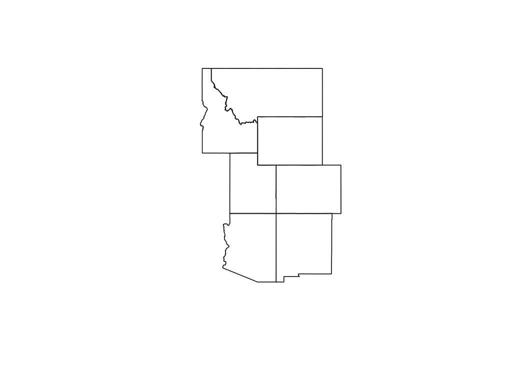

```r
plot(thewest$geometry)
```

Okay, time to get everything into the same projection. From M. Williamson: “Because the mammal richness data is the largest, we’ll project everything to that and then crop.”

```r
#checking shape files
st_crs(pas)$proj4string
```

```
## [1] "+proj=aea +lat_0=23 +lon_0=-96 +lat_1=29.5 +lat_2=45.5 +x_0=0 +y_0=0 +datum=NAD83 +units=m +no_defs"
```

```r
st_crs(thewest)$proj4string
```

```
## [1] "+proj=longlat +datum=NAD83 +no_defs"
```

```r
#checking rasters
crs(mammal.rich, proj=TRUE)
```

```
## [1] "+proj=aea +lat_0=37.5 +lon_0=-96 +lat_1=29.5 +lat_2=45.5 +x_0=0 +y_0=0 +datum=NAD83 +units=m +no_defs"
```

```r
crs(landval, proj= TRUE)
```

```
## [1] "+proj=aea +lat_0=23 +lon_0=-96 +lat_1=29.5 +lat_2=45.5 +x_0=0 +y_0=0 +datum=NAD83 +units=m +no_defs"
```

We can see that the PAs shape file and the landval raster are in the same projection, but “thewest” shapefile and the mammal.rich raster do not match the others. BUT… we need to project everything to the mammal.rich raster and then crop it down.

```r
#TURNING shape files into Spat Vectors so we can work with them alongside raster files
pa.vect<-as(pas, "SpatVector")
thewest.vect<-as(thewest, "SpatVector")
```

Now time to project to the mammal.rich raster

```r
pa.vect.proj<-project(pa.vect, mammal.rich)
thewest.vect.proj<-project(thewest.vect, mammal.rich)
landval.proj<-project(landval, mammal.rich)
```

And, finally, crop everything down to “the west”- or western United States of interest

```r
#pa.vect.proj should already match "thewest"
mammal.rich.crop<-crop(mammal.rich, thewest.vect.proj)
landval.crop<-crop(landval.proj, thewest.vect.proj)
```

Rechecking CRS on everything(this step is really for my own peace of mind)

```r
crs(mammal.rich.crop, proj=TRUE)
```

```
## [1] "+proj=aea +lat_0=37.5 +lon_0=-96 +lat_1=29.5 +lat_2=45.5 +x_0=0 +y_0=0 +datum=NAD83 +units=m +no_defs"
```

```r
crs(landval.crop, proj= TRUE)
```

```
## [1] "+proj=aea +lat_0=37.5 +lon_0=-96 +lat_1=29.5 +lat_2=45.5 +x_0=0 +y_0=0 +datum=NAD83 +units=m +no_defs"
```

```r
crs(pa.vect.proj, proj=TRUE)
```

```
## [1] "+proj=aea +lat_0=37.5 +lon_0=-96 +lat_1=29.5 +lat_2=45.5 +x_0=0 +y_0=0 +datum=NAD83 +units=m +no_defs"
```

```r
crs(thewest.vect.proj, proj=TRUE)
```

```
## [1] "+proj=aea +lat_0=37.5 +lon_0=-96 +lat_1=29.5 +lat_2=45.5 +x_0=0 +y_0=0 +datum=NAD83 +units=m +no_defs"
```

```r
#ALL MATCH
```

Next step: “Adding ‘population’ to our census data by making a change to our tidycensus call.” (Before we had just pulled median income). “SPREAD will be used here to move the data into WIDE format.”

```r
library(tidycensus)
census_api_key("5b7ad661cf6e4de1e552c4b0707dedfe686fbc72")
```

```
## To install your API key for use in future sessions, run this function with `install = TRUE`.
```

```r
west.census<-get_acs(geography= "county",
                     variables = c(medianincome = "B19013_001",
                            pop = "B01003_001"),
                     state = c("ID", "MT", "WY", "UT", "CO","AZ", "NM"),
                     year = 2018,
                     geometry = TRUE) %>%
                    st_transform(.,crs(pa.vect.proj)) %>%
                    select(-moe) %>%
                    spread(variable, estimate)
```

Next, “we’ll do the necessary extractions and join everything together into a single dataframe that we can use for plotting.”  
First, join the census data to our pa dataset. Then we will filter and summarise some of the data.

```r
#have to convert pas back into an sf object (from SpatVector) to join with the census data
pa.summary<- st_join(st_as_sf(pa.vect.proj), west.census, join = st_overlaps)
class(pa.summary)
```

```
## [1] "sf"         "data.frame"
```

```r
head(pa.summary)
```

```
## Simple feature collection with 6 features and 36 fields
## Geometry type: GEOMETRY
## Dimension:     XY
## Bounding box:  xmin: -1252938 ymin: -572972 xmax: -855204.7 ymax: 303877.6
## Projected CRS: USA_Contiguous_Albers_Equal_Area_Conic
##        Category Mang_Name Des_Tp
## 1   Designation       BLM     NM
## 2   Designation       BLM     NM
## 2.1 Designation       BLM     NM
## 2.2 Designation       BLM     NM
## 3   Designation       BLM     NM
## 4   Designation       BLM     NM
##                                              Unit_Nm State_Nm GAP_Sts IUCN_Cat
## 1                         Jurassic National Monument       UT       2      III
## 2                    Browns Canyon National Monument       CO       2        V
## 2.1                  Browns Canyon National Monument       CO       2        V
## 2.2                  Browns Canyon National Monument       CO       2        V
## 3          Kasha-Katuwe Tent Rocks National Monument       NM       2        V
## 4   Organ Mountains - Desert Peaks National Monument       NM       2        V
##     Own_Typ Own_Nam Loc_Own Mng_Typ Loc_Mng Loc_Ds Loc_Nm Agg_Src GIS_Src
## 1      <NA>    <NA>    <NA>    <NA>    <NA>   <NA>   <NA>    <NA>    <NA>
## 2      <NA>    <NA>    <NA>    <NA>    <NA>   <NA>   <NA>    <NA>    <NA>
## 2.1    <NA>    <NA>    <NA>    <NA>    <NA>   <NA>   <NA>    <NA>    <NA>
## 2.2    <NA>    <NA>    <NA>    <NA>    <NA>   <NA>   <NA>    <NA>    <NA>
## 3      <NA>    <NA>    <NA>    <NA>    <NA>   <NA>   <NA>    <NA>    <NA>
## 4      <NA>    <NA>    <NA>    <NA>    <NA>   <NA>   <NA>    <NA>    <NA>
##     Src_Dat       GIS_Acr Sr_PAID       WDPA_Cd Pb_Accs Accss_S Accss_D GAPCdSr
## 1      <NA> -9.223372e+18    <NA> -9.223372e+18    <NA>    <NA>    <NA>    <NA>
## 2      <NA> -9.223372e+18    <NA> -9.223372e+18    <NA>    <NA>    <NA>    <NA>
## 2.1    <NA> -9.223372e+18    <NA> -9.223372e+18    <NA>    <NA>    <NA>    <NA>
## 2.2    <NA> -9.223372e+18    <NA> -9.223372e+18    <NA>    <NA>    <NA>    <NA>
## 3      <NA> -9.223372e+18    <NA> -9.223372e+18    <NA>    <NA>    <NA>    <NA>
## 4      <NA> -9.223372e+18    <NA> -9.223372e+18    <NA>    <NA>    <NA>    <NA>
##     GAPCdDt IUCNCtS IUCNCtD Dat_Est Commnts SHAPE_L SHAPE_A FetClss GEOID
## 1      <NA>    <NA>    <NA>    <NA>    <NA>      NA      NA    <NA>  <NA>
## 2      <NA>    <NA>    <NA>    <NA>    <NA>      NA      NA    <NA> 08015
## 2.1    <NA>    <NA>    <NA>    <NA>    <NA>      NA      NA    <NA> 08043
## 2.2    <NA>    <NA>    <NA>    <NA>    <NA>      NA      NA    <NA> 08093
## 3      <NA>    <NA>    <NA>    <NA>    <NA>      NA      NA    <NA>  <NA>
## 4      <NA>    <NA>    <NA>    <NA>    <NA>      NA      NA    <NA> 35013
##                                   NAME medianincome    pop
## 1                                 <NA>           NA     NA
## 2             Chaffee County, Colorado        54580  19164
## 2.1           Fremont County, Colorado        46296  47002
## 2.2              Park County, Colorado        66861  17392
## 3                                 <NA>           NA     NA
## 4   Doña Ana County, New Mexico        39164 215338
##                           geometry
## 1   POLYGON ((-1252858 301852.5...
## 2   POLYGON ((-866222.9 176827....
## 2.1 POLYGON ((-866222.9 176827....
## 2.2 POLYGON ((-866222.9 176827....
## 3   POLYGON ((-936621 -155512.9...
## 4   MULTIPOLYGON (((-996451 -54...
```

```r
pa.summary.filt<- pa.summary %>%
  group_by(Unit_Nm) %>%
  summarize(., meaninc = mean(medianincome, na.rm= TRUE),
            meanpop = mean(pop, na.rm= TRUE))
#double checking to see if I have the right number of rows. "Unit_Nm" refers to the name of each protected area
nrow(pa.summary.filt) == length((unique(pas$Unit_Nm)))
```

```
## [1] TRUE
```

```r
#True
```

Onto the extractions

```r
#again, working with the PA SPAT VECTOR! (because we are working with analysis in raster data)
pas$Unit_Nm
```

```
##   [1] "Jurassic National Monument"
##   [2] "Browns Canyon National Monument"
##   [3] "Kasha-Katuwe Tent Rocks National Monument"
##   [4] "Organ Mountains - Desert Peaks National Monument"
##   [5] "Prehistoric Trackways National Monument"
##   [6] "Río Grande Del Norte National Monument"
##   [7] "Río Grande Del Norte National Monument"
##   [8] "Vermilion Cliffs National Monument"
##   [9] "Bears Ears National Monument - Indian Creek Unit"
##  [10] "Bears Ears National Monument - Shash Jáa Unit"
##  [11] "Canyons Of The Ancients National Monument"
##  [12] "Canyons Of The Ancients National Monument"
##  [13] "Craters Of The Moon National Monument"
##  [14] "Grand Staircase-Escalante National Monument - Escalante Canyons Unit"
##  [15] "Grand Staircase-Escalante National Monument - Grand Staircase Unit"
```

[output cut: 209 more lines]

```r
#REMEMBER: RASTERIZE "Transfers values associate with 'vector' type spatial data (points, lines, polygons) to the spatially overlapping raster cells." x is the SPAT VECT and y is the raster object. Again, think of it as laying out a stencil for your rasters. The stencil is your shape file(really SpatVector) or lines, points, etc/
#rasterize
pa.zones<-terra::rasterize(pa.vect.proj, mammal.rich.crop, field= "Unit_Nm")
#extracting using the "stencil"
mammal.zones<-terra::zonal(mammal.rich.crop, pa.zones, fun= "mean", na.rm=TRUE)
landval.zones<-terra::zonal(landval.crop, pa.zones, fun = mean, na.rm=TRUE)
#"Note that there is one few zone than we have in our PA dataset. This is because we have an overlapping jurisdicition; we'll ingnore that now but it's a common problement with using the PADUS"
```

**COMBINING EVERYTHING INTO ONE LARGE DATAFRAME! (I did this the hard way on MINI PROJECT 1!)

```r
class(pa.summary.filt) #sf
```

```
## [1] "sf"         "tbl_df"     "tbl"        "data.frame"
```

```r
class(mammal.zones) #df
```

```
## [1] "data.frame"
```

```r
class(landval.zones) #df
```

```
## [1] "data.frame"
```

```r
summary.df<- pa.summary.filt %>%
  left_join(., mammal.zones) %>%
              left_join(., landval.zones)
```

# Task 3: Build a map with Tmap

Practice making a quick map with tmap.

From M. Williamson’s example:  
“Up until now, we’ve been using the base::plot function to generate rapid visualizations of our data. That’s fine, but it takes a fair amount of work to get those graphics into something resembling a publication-quality map. The tmap package is a versatile package designed specifically for making thematic maps. It generally builds on the grammar of graphics logic and follows most of the ggplot2 conventions. It’s not quite as flexible as ggplot2 and doesn’t allow easy integration for different types of non-spatial figures (but see patchwork for ways to address this); however, it has a lot of functionality for both static and interactive mapping and deals with raster datasets in a way that is more intuitive than ggplot2. I’ll introduce a few of the features here, but I would encourage you to take a look at Manuel Gimond’s set of notes and the tmap intro pages to get broader exposure to the capabilities of tmap. We’ll revisit some of these next week, but let’s get started with some simple examples.”

Also… *tm_shape: “specifies which dataset we are talking about”* tm_polygons: “allows you to the specify a number of additional gg elements including aesthetics. For example tm_polygons(col =”meanpop“, border.col=”white)+ tm_legend(outside=TRUE)"

“There are a variety of tm_* functions.”

I’ll do mean income since the example does population.

**NOTE: IT DOES MATTER IN WHICH ORDER YOU STACK THE LAYERS! So do the raster first and then stack everything else on top!**

```r
library(tmap)
?tmap
current.mode <- tmap_mode("plot")
```

```
## tmap mode set to plotting
```

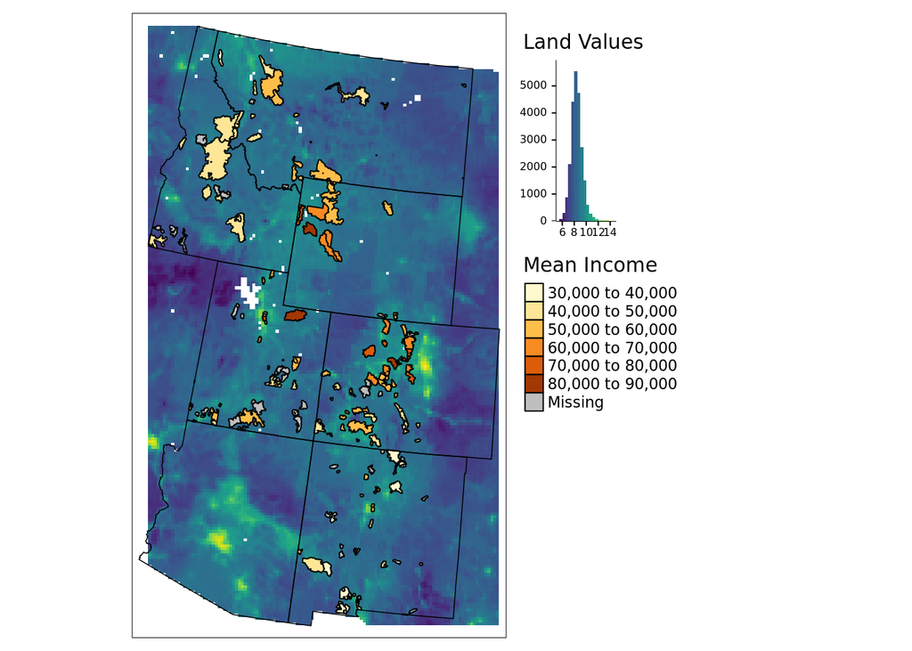

```r
tm_shape(landval.crop)+tm_raster(palette = viridis(n=100), n=100, legend.show = FALSE, legend.hist = TRUE, legend.hist.title = "Land Values")+
tm_shape(summary.df) +
  tm_polygons(col= "meaninc", border.col= "black", title="Mean Income")+
  tm_legend(outside = TRUE) +
tm_shape(thewest)+tm_borders("black", lwd = 0.75)
```

```r
#I had to go back in the code and remove "NV" from the states since our original landval raster's extent does not go this far
```

# Task 4: Build a choropleth with ggplot

Your map should have a basemap, should rely on more than one aesthetic (color, transparency, etc), and combine multiple layers.

From M. Williamson’s notes: “The tmap approach is relatively straigtforward and may achieve all you ever hope for in map production. That said, ggplot2 is generally the “industry standard” for plotting in R. That doesn’t mean it’s the best, or the easiest; but it is under constant development to accomodate more and more different kinds of data."

*“mapping = aes() is the call that specifies the mapping between the data and the aesthetics”* “geom_ call specifies the geometric element. In this case”geom_sf" tells ggplot to map in mapping=aes(x=longitude, y=latitude)"

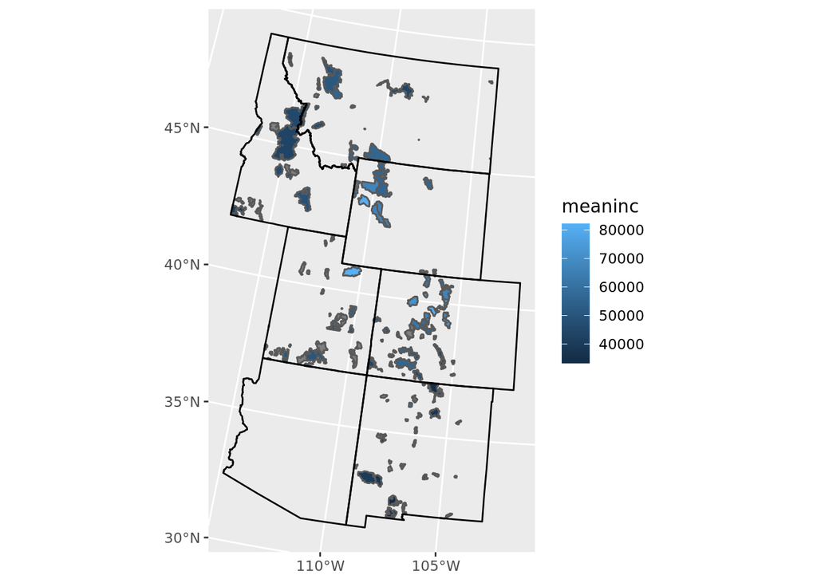

```r
ggplot(summary.df) +
  geom_sf(mapping = aes(fill=meaninc))+
  geom_sf(data = thewest, fill=NA, color= "black")
```

“Now let’s add a little fanciness by adding a basemap from ggmap (check out the ?ggmap and ?get_map for details)”

```r
bg<-ggmap::get_map(as.vector(st_bbox(thewest)))
```

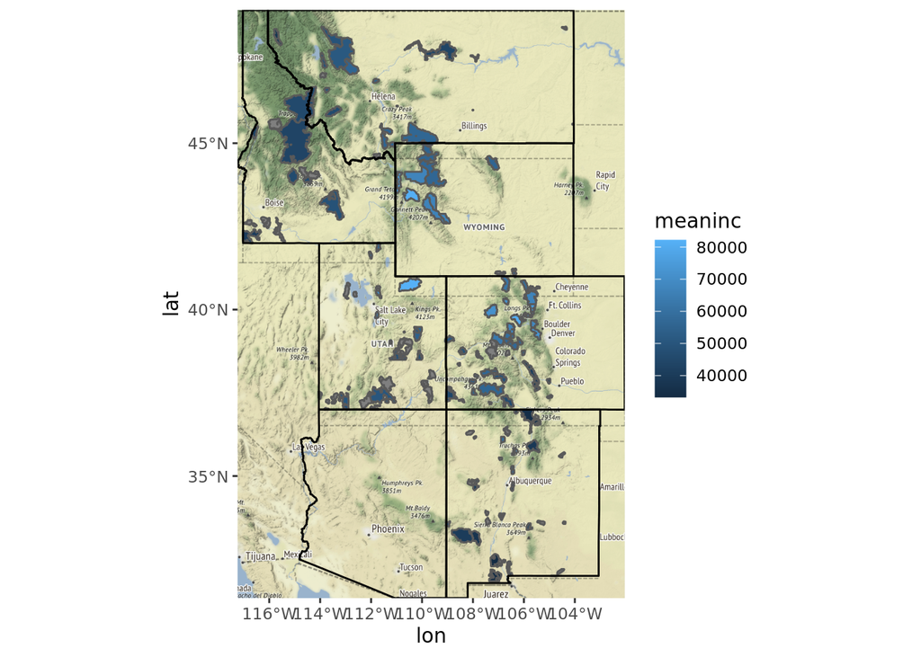

```r
ggmap(bg) +
  geom_sf(data=summary.df, mapping= aes(fill=meaninc), inherit.aes = FALSE)+
  geom_sf(data= thewest, fill=NA, color="black", inherit.aes= FALSE)+
  coord_sf(crs = st_crs(4326))
```

**NOTE:** From M. Williamson: "We are still building the map layer-by-layer, but in this case had to use ggmap to get R to recognize that we wanted to use the downloaded file as the base for the plot. We also have to use inherit.aes=FALSE to allow each additional geom to have it’s own set of aesthetics. Finally, we use **coord_sf() to add a new coordinate system to the map because ggmap downloads everything in WGS84."**

**I am having the same issue with this that Jessica and Kirsten had where the base map dotted lines are not lining up with our state boundary lines.**

More notes from M. Williamson: “Now that we have things starting to look nice, let’s see if we can add a few more aesthetics and introduce a scale.”

ggmap(bg) + geom_sf(data = summary.df, mapping = aes(fill = Value, alpha = (idval - max(idval, na.rm=TRUE))/(max(idval, na.rm=TRUE)-min(idval, na.rm = TRUE))), inherit.aes = FALSE) + geom_sf(data=id, fill=NA,color=“black”, inherit.aes = FALSE) + scale_fill_viridis(option=“magma”)+ coord_sf(crs = st_crs(4326))

“Here we’ve added an additional aesthetic mapping for alpha which sets the transparency and then used scale_fill_viridis_ to map the species richness value to the viridis color palette. We’ve then ‘softened’ that color based on the cost of land in that area. You can find additional palettes and options using the ?scale_fill_ helpfiles.”

(I couldn’t get this to work with my code, even with subbing out variables.It is as if we are missing a variable in our summary table.)

# Task 5: Build 2 cartograms

Follow the examples to build cartograms that display your region of interest based on variables other than area.

```r
west_pop<-cartogram_cont(west.census, "pop", itermax = 5)
```

```
## Mean size error for iteration 1: 7.97191455549748
```

```
## Mean size error for iteration 2: 6.98304805061679
```

```
## Mean size error for iteration 3: 6.1718595170077
```

```
## Mean size error for iteration 4: 5.43363913810071
```

```
## Mean size error for iteration 5: 4.74369766684802
```

```r
west_income<-cartogram_cont(west.census, "medianincome", itermax = 5)
```

```
## Mean size error for iteration 1: 2.26920949468362
```

```
## Mean size error for iteration 2: 1.67570354852594
```

```
## Mean size error for iteration 3: 1.37782878606263
```

```
## Mean size error for iteration 4: 1.21614562482343
```

```
## Mean size error for iteration 5: 1.12828828497879
```

```r
#First, population
tm_shape(west_pop)+tm_polygons("pop", style= "jenks")+ tm_layout(frame=FALSE, legend.position = c("left", "center"))
```

```
## Some legend labels were too wide. These labels have been resized to 0.53, 0.53, 0.48, 0.44. Increase legend.width (argument of tm_layout) to make the legend wider and therefore the labels larger.
```

[figure not shown]

```r
#Now income
tm_shape(west_income) +tm_polygons("medianincome", style= "jenks")+
  tm_layout(frame=FALSE, legend.position = c("right", "bottom"))
```

```
## Legend labels were too wide. The labels have been resized to 0.62, 0.62, 0.62, 0.62, 0.58. Increase legend.width (argument of tm_layout) to make the legend wider and therefore the labels larger.
```

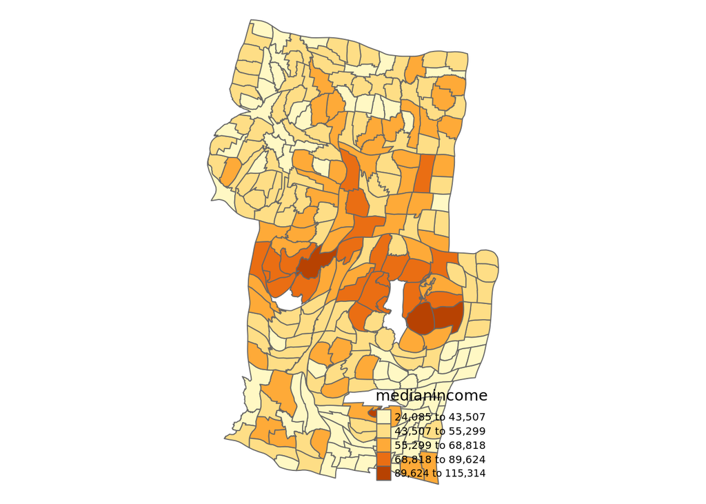

**Question 3:** Reflect on the different maps you’ve made, what do the different visualizations tell you about the data you plotted?  
TMAP: Generally speaking, I see a fairly decent trend that suggests landvalues are higher near protected areas. And for the most part, mean income is also higher near higher landvalue areas. GGPLOT: Well, considering I couldn’t get the second plot to work re: scale, I feel like this ggplot map doesn’t tell us a whole lot. But, it’s nice to look at and probably easy for people to understand. You can easily see which protected areas are associated with high median incomes and in which states this occurs. There appear to be very general statewide trends. CARTOGRAM: I love these because I think they are really intuitive. We can see there are high population counts in the bulging areas of Arizona, Utah and Colorado. Two of the three areas (Utah and Colorado) also have high median incomes, while Arizona has a low median income, compartively. Funny enough, it looks like there is a huge bulge in southern Idaho for lower median incomes.

**Question 4:** How might you improve the maps you’ve made?  
For the tmap, I don’t love that you can’t see the raster value *within* the protected area, so I think if there were some way to “map” that value. I also don’t like how there are very few geographical reference points in the map (i.e. no state names or other anchoring points). For someone that is not familiar with this geography, this could be confusing. For the ggplot map, the ggmap function is really neat and makes the map more aesthetically pleasing, but I feel like some of the information is lost (so almost the opposite problem of the tmap). However, I think if I had been able to work with the scale function, this would have made the map even more informative. For the cartogram, I would like to add some sort of outline for state boundaries so you have some sort of reference point. When you are covering such a large area(multiple points), you are kinda of just guessing about where you are on the map unless you know the area really well. A cartogram is probably more appropriate for a smaller extent (like one state) or for a question where boundaries are less important.

**Question 5:** Is a map the best way to evaluate the data you worked with? Why or Why not? For basic summary statistics- maybe. But for everything else- not really. You really can only make “generalizations” of the data you are seeing on the map. But none of this is definitive. I mean, realistically, a peer-reviewed scientific journal is not going to accept objective observations as a means for analysis. But perhaps I am not aware of different packages that can be used to effectively analyze these maps? That said, I do think being able to visualize data, and present this data, is imperative to communicating your research effectively to the lay person and the rest of the scientific community.